# Hitting in the MLB: Steroid Era vs Modern Era

Author

Matthew Gutierrez

## Introduction

I’ve always been curious about whether steroids really led to better hitting during the steroid era in baseball. Specifically, I want to explore how much performance-enhancing drugs, particularly from 1994 to 2004, boosted key hitting stats compared to modern baseball (2013-2023). While power hitting and home runs surged during the steroid era, I aim to understand if steroids were a major factor or if other variables played a role.

### Primary Questions

1. What is the relationship between steroid-era and modern-era hitting performance?
   - Specifically, I expect to find that players from the steroid era had better performance metrics across all categories such as batting average, RBIs, home runs, and slugging percentage compared to modern players.
2. Is there a significant difference in hitting statistics like home runs, RBIs, and batting averages between the two eras?

## Data

The data used for this analysis comes from the Lahman baseball database, which include player statistics for both the steroid era and the modern era. Below is the code to import and wrangle the data to fit my analysis:

```r
library(Lahman)
library(dplyr)
library(ggplot2)

# Code to load the Batting data
data("Batting")

# Code to split data into steroid era (1994-2004) and modern era (2013-2023)
steroid_era <- Batting %>% filter(yearID >= 1994 & yearID <= 2004)
modern_era <- Batting %>% filter(yearID >= 2013 & yearID <= 2023)
```

There is never a reason for you to print an entire data frame within a document. If you want to provide something that can show your data, you can use the `paged_table` function:

```r
head(steroid_era)
```

```
   playerID yearID stint teamID lgID  G  AB  R  H X2B X3B HR RBI SB CS BB SO
1 aardsda01   2004     1    SFN   NL 11   0  0  0   0   0  0   0  0  0  0  0
2  abadan01   2001     1    OAK   AL  1   1  0  0   0   0  0   0  0  0  0  0
3  abadan01   2003     1    BOS   AL  9  17  1  2   0   0  0   0  0  1  2  5
4 abbotje01   1997     1    CHA   AL 19  38  8 10   1   0  1   2  0  0  0  6
5 abbotje01   1998     1    CHA   AL 89 244 33 68  14   1 12  41  3  3  9 28
6 abbotje01   1999     1    CHA   AL 17  57  5  9   0   0  2   6  1  1  5 12
  IBB HBP SH SF GIDP
1   0   0  0  0    0
2   0   0  0  0    0
3   0   0  0  0    1
4   0   0  0  0    3
5   1   0  2  5    2
6   0   0  1  1    4
```

```r
head(modern_era)
```

```
   playerID yearID stint teamID lgID  G AB R H X2B X3B HR RBI SB CS BB SO IBB
1 aardsda01   2013     1    NYN   NL 43  0 0 0   0   0  0   0  0  0  0  0   0
2 aardsda01   2015     1    ATL   NL 33  1 0 0   0   0  0   0  0  0  0  1   0
3  abadfe01   2013     1    WAS   NL 39  0 0 0   0   0  0   0  0  0  0  0   0
4  abadfe01   2014     1    OAK   AL 69  0 0 0   0   0  0   0  0  0  0  0   0
5  abadfe01   2015     1    OAK   AL 62  0 0 0   0   0  0   0  0  0  0  0   0
6  abadfe01   2016     1    MIN   AL 39  1 0 0   0   0  0   0  0  0  0  1   0
  HBP SH SF GIDP
1   0  0  0    0
2   0  0  0    0
3   0  0  0    0
4   0  0  0    0
5   0  0  0    0
6   0  0  0    0
```

My data came in clean as it is a loaded package within R. I used this code to manipulate the data to look at the important parts of hitting such as batting average, RBIs, home runs, and OPS (On base plus slugging), which is a commonly used power hitting statistic.

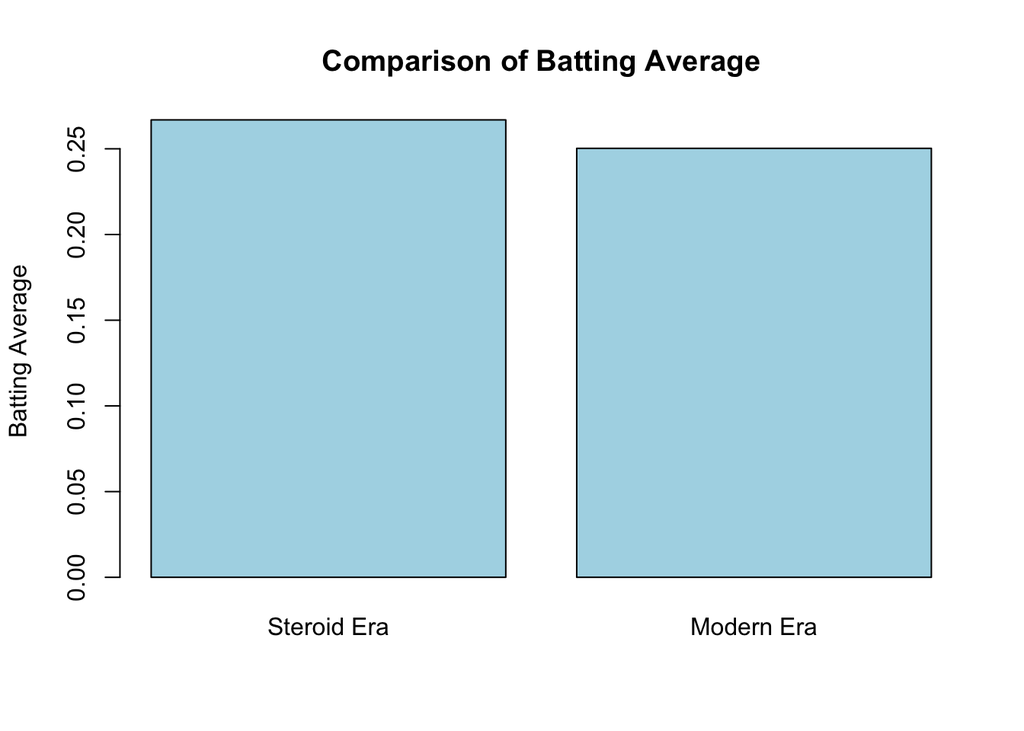

```r
# Code summarize key statistics for the steroid era
steroid_summary <- steroid_era %>%
  summarize(
    total_AB = sum(AB, na.rm = TRUE),
    total_H = sum(H, na.rm = TRUE),
    total_HR = sum(HR, na.rm = TRUE),
    total_RBI = sum(RBI, na.rm = TRUE),
    avg_BA = sum(H, na.rm = TRUE) / sum(AB, na.rm = TRUE),
    avg_OBP = sum(H + BB + HBP, na.rm = TRUE) / sum(AB + BB + HBP + SF, na.rm = TRUE),
    avg_SLG = sum(H + X2B + 2 * X3B + 3 * HR, na.rm = TRUE) / sum(AB, na.rm = TRUE),
    avg_OPS = avg_OBP + avg_SLG
  )

# Code summarize key statistics for the modern era
modern_summary <- modern_era %>%
  summarize(
    total_AB = sum(AB, na.rm = TRUE),
    total_H = sum(H, na.rm = TRUE),
    total_HR = sum(HR, na.rm = TRUE),
    total_RBI = sum(RBI, na.rm = TRUE),
    avg_BA = sum(H, na.rm = TRUE) / sum(AB, na.rm = TRUE),
    avg_OBP = sum(H + BB + HBP, na.rm = TRUE) / sum(AB + BB + HBP + SF, na.rm = TRUE),
    avg_SLG = sum(H + X2B + 2 * X3B + 3 * HR, na.rm = TRUE) / sum(AB, na.rm = TRUE),
    avg_OPS = avg_OBP + avg_SLG
  )

# Code to create a comparison data frame
comparison <- data.frame(
  Era = c("Steroid Era", "Modern Era"),
  Avg_BA = c(steroid_summary$avg_BA, modern_summary$avg_BA),
  Total_HR = c(steroid_summary$total_HR, modern_summary$total_HR),
  Total_RBI = c(steroid_summary$total_RBI, modern_summary$total_RBI),
  Avg_OPS = c(steroid_summary$avg_OPS, modern_summary$avg_OPS)
)

# Code to show Batting Average difference
bar_heights <- barplot(
  comparison$Avg_BA,
  names.arg = comparison$Era,
  main = "Comparison of Batting Average",
  ylab = "Batting Average",
  col = "lightblue"
  )
```

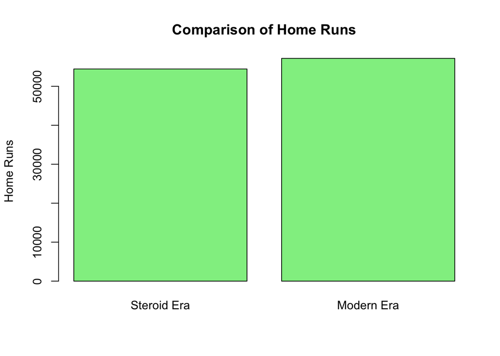

```r
# Code to show Home Run difference
bar_heights <- barplot(
  comparison$Total_HR,
  names.arg = comparison$Era,
  main = "Comparison of Home Runs",
  ylab = "Home Runs",
  col = "lightgreen"
  )
```

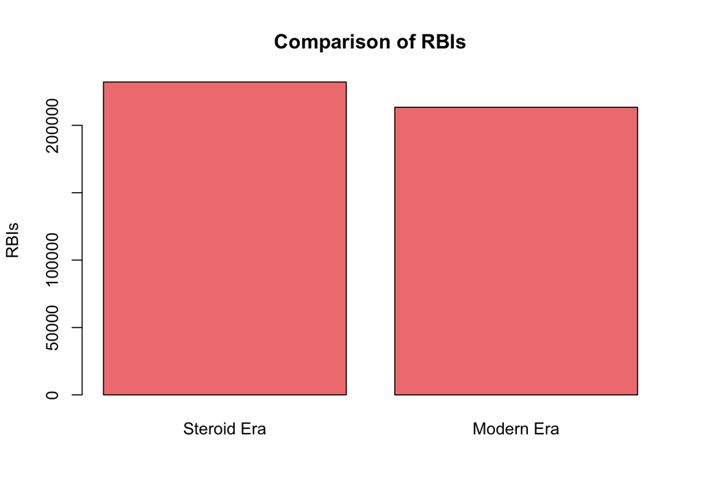

```r
# Code to show RBI difference
bar_heights <- barplot(
  comparison$Total_RBI,
  names.arg = comparison$Era,
  main = "Comparison of RBIs",
  ylab = "RBIs",
  col = "lightcoral"
  )
```

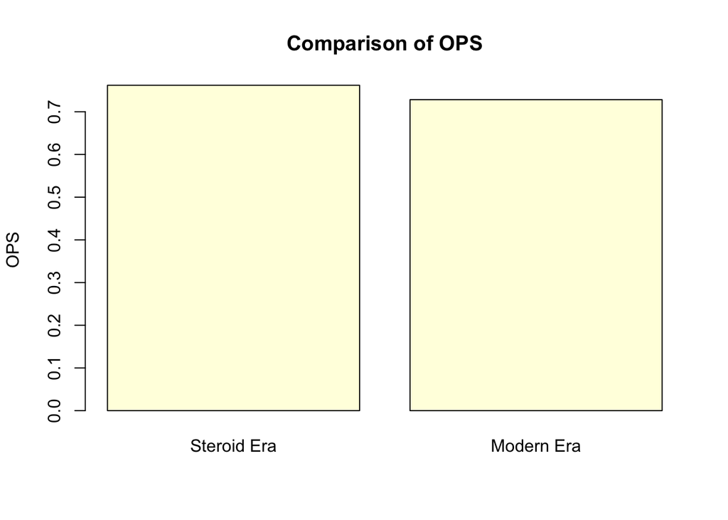

```r
# Code to show OPS difference
bar_heights <- barplot(
  comparison$Avg_OPS,
  names.arg = comparison$Era,
  main = "Comparison of OPS",
  ylab = "OPS",
  col = "lightyellow"
  )
```

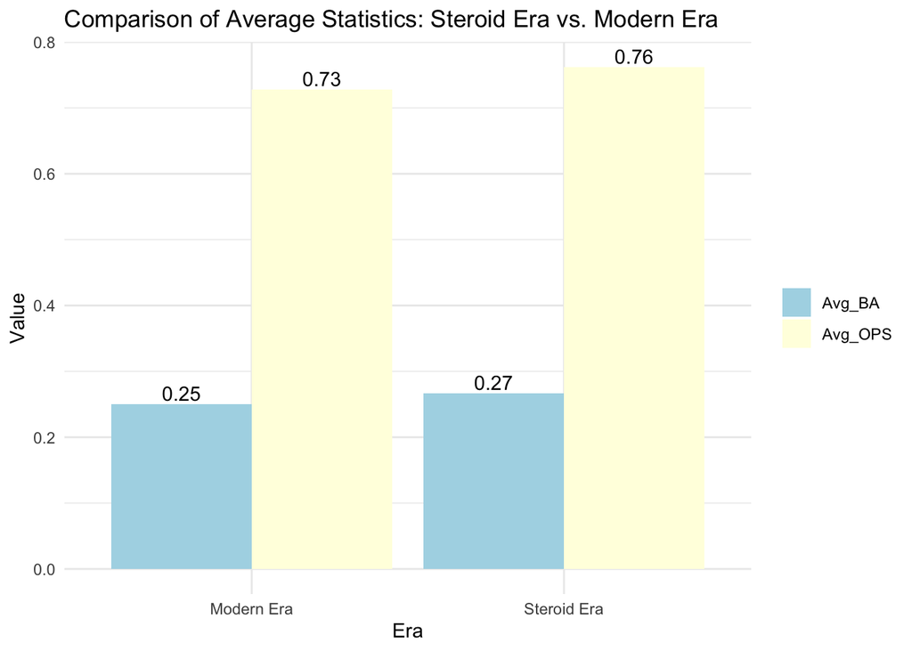

```r
# Code to melt the data frame for easier plotting with ggplot
library(reshape2)
comparison_melted <- melt(comparison, id.vars = "Era")

comparison_avg <- subset(comparison_melted, variable %in% c("Avg_BA", "Avg_OPS"))

ggplot(comparison_avg, aes(x = Era, y = value, fill = variable)) +
  geom_bar(stat = "identity", position = "dodge") +
  labs(
    title = "Comparison of Average Statistics: Steroid Era vs. Modern Era",
    y = "Value",
    x = "Era"
  ) +
  theme_minimal() +
  scale_fill_manual(values = c("Avg_BA" = "lightblue", "Avg_OPS" = "lightyellow")) +
  theme(legend.title = element_blank()) +
  geom_text(aes(label = round(value, 2)), position = position_dodge(width = 0.9), vjust = -0.25)
```

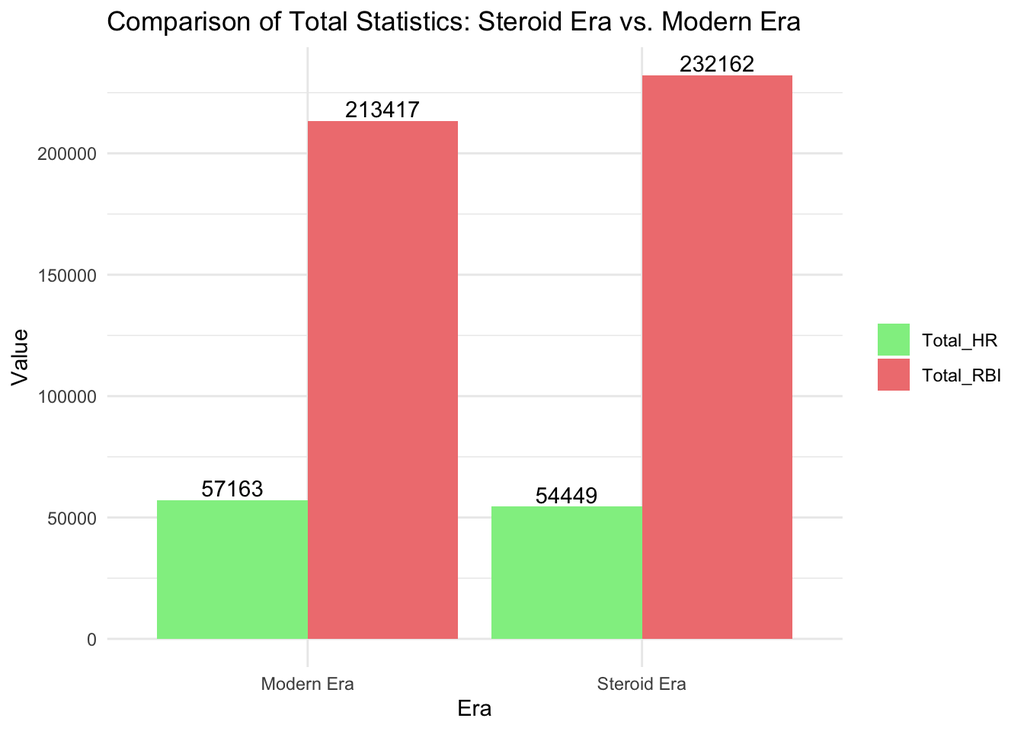

```r
# Code used to create a ggplot bar plot comparing percentages (HR and RBI)
comparison_total <- subset(comparison_melted, variable %in% c("Total_HR", "Total_RBI"))

ggplot(comparison_total, aes(x = Era, y = value, fill = variable)) +
  geom_bar(stat = "identity", position = "dodge") +
  labs(
    title = "Comparison of Total Statistics: Steroid Era vs. Modern Era",
    y = "Value",
    x = "Era"
  ) +
  theme_minimal() +
  scale_fill_manual(values = c("Total_HR" = "lightgreen", "Total_RBI" = "lightcoral")) +
  theme(legend.title = element_blank()) +
  geom_text(aes(label = round(value, 2)), position = position_dodge(width = 0.9), vjust = -0.25)
```